# HOW CAN A WELLNESS COMPANY CAN PLAY IT SMART

OLABISI FAYOSE

2023-01-17

## CLIENT : BELLABEAT

## EXECUTIVE SUMMARY

Although BellaBeat is quite successful but,they want to be a major player in the Global market. They are interested in knowing more about consumer trends and key marketing success factors in the fitness tracker market in order to help develop their marketing strategy.

## PROJECT OBJECTIVE/BUSINESS TASK

- FOCUS ON ONE BELLABEAT PRODUCT
- ANALYZE A SMART DEVICE DATA TO GAIN INSIGHT INTO HOW CONSUMERS ARE USING THEIR SMART DEVICE.
- USE THE INSIGHTS GENERATED TO GUIDE A MARKETING STRATEGY FOR THE BELLABEAT COMPANY

## The Dataset

### DATA INTEGRITY

- using the ROCCC test, the dataset is certified credible for the data analysis

reliable Original, Comprehensive - it shows how consumers use their trackers Current - based on assumption the analysis demand was made in 2017 Cited - cited * It is also unbiased.

### CLEANING

- NO DUPLICATES found
- No null values found
- Convertion of dates from character class to date class was carried out where necessary. Details are in the findings

## Market trends

- Global fitness tracker market size went from USD17 million in 2016 to $41 billion in 2021 and is expected to be 114B by year 2028 at a CAGR of 15.4%.link
- The growth is attributed to increase in healthcare awareness, rise in the number of manufacturers offering various fitness trackers at affordable prices and increased prevalence of Health disorders like obesity, diabetes, cardiovascular diseases etc.Another of the major causes of the surge was COVID_19 pandemic. *Growth limited by risk of data theft

- Market share as illustrated in the chart. Market dominated by Apple.

```r
library(tidyverse)
mark <- read.csv("C://Users//ACER//Downloads//Untitled spreadsheet - Sheet1 (1).csv")
```

```r
head(mark)
```

```
##   YEAR MARKET.SHARE   BRAND
## 1 2021         30.3   APPLE
## 2 2021         10.3  XIAOMI
## 3 2021          8.0  HUAWEI
## 4 2021          9.0 SAMSUNG
## 5 2021          0.0  FITBIT
## 6 2021          0.0  GARMIN
```

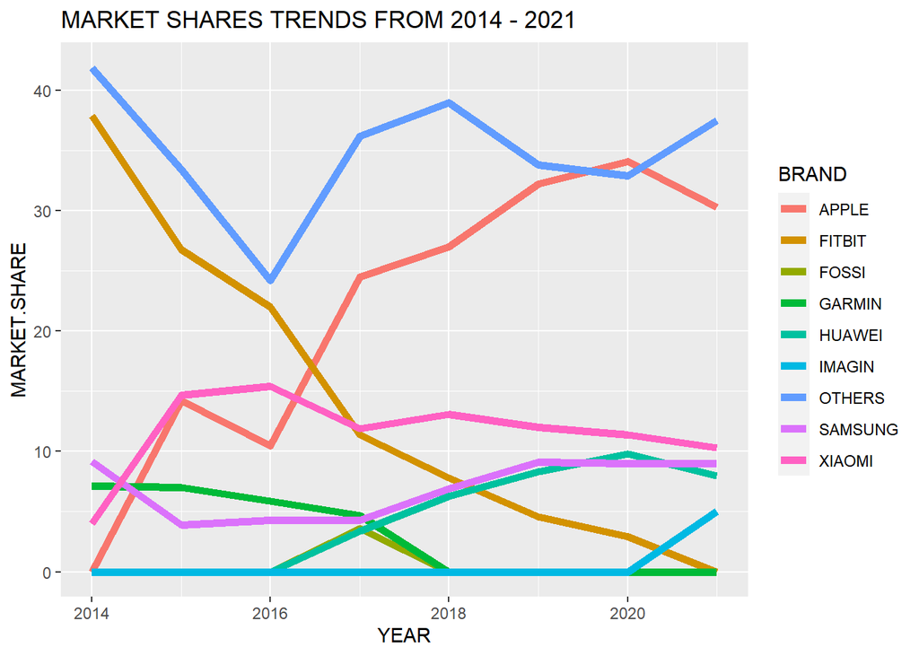

```r
mark %>%
  ggplot(aes(YEAR, MARKET.SHARE, color = BRAND))+
  geom_line(size = 2)+
  labs(title = "MARKET SHARES TRENDS FROM 2014 - 2021")
```

### MARKET SEGMENTS

#### DEVICE TYPE SEGMENT

- Smartwatches
- WristBands
- Smart Glasses
- Smart Clothings
- Others Dominated by SmartWatches 40% in 2020

#### REGIONAL SEGMENT

- North America
- Europe
- Asia Pacific
- Latin America
- Middle East & Africa Dominated by North America 42% in 2020

## FINDINGS

### GENERAL

- There were different number of respondents tracked the different applications. Maybe because they had different devices with different functions
- Not all respondents track everyday
- Applications tracked include
  1. Physical Activities 2. Steps 3. Heart rate, 4. Sleep, 5. Calories burnt, 6. METs
- IMPORT FILES. Although there are 18 data sets, we will not be importing all because some of them have been merged into one dataframe viz: Activities, steps, calories burnt, time spent on activities etc.
- Set up the environment by running these libraries

```r
library(tidyverse)
```

```r
library(GGally)
library(lubridate)
```

```r
library(ggplot2)
```

### sleep

```r
sleep <- read.csv("C://Users//ACER//Downloads//sleepDay_merged.csv")
```

- Only 24 respondents tracked their sleep.

```r
unique(sleep$k)
```

```
##  [1] 1503960366 1644430081 1844505072 1927972279 2026352035 2320127002
##  [7] 2347167796 3977333714 4020332650 4319703577 4388161847 4445114986
## [13] 4558609924 4702921684 5553957443 5577150313 6117666160 6775888955
## [19] 6962181067 7007744171 7086361926 8053475328 8378563200 8792009665
## [25]         NA
```

- time spent in bed was tracked and differentiated from time spent sleeping *time spent sleeping
- Recommended sleep time is 7-9hours a day. Average sleep time is 6.9hours. See code below.

```r
summary(sleep$TOTAL.HOURS)
```

```
##    Min. 1st Qu.  Median    Mean 3rd Qu.    Max.    NA's
##   0.000   6.020   7.200   6.958   8.170  13.270      19
```

- quality of sleep was tracked and segregated into 3 categories 1, 2 3. 1== Deep sleep, 2 == REM or RAPID EYE MOVEMENT, 3 == light sleep Of which deep sleep is the best.Respondents generally sleep deeply as shown below. In the dataset quality of sleep was recorded as 1, 2, 3, but i later did a recode to deep, REM and light for better understanding. See code chunck below

```r
sleep$TotalSleepRecords = factor(sleep$TotalSleepRecords)
sleep$TotalSleepRecords2[sleep$TotalSleepRecords == "1"] = "deep"
sleep$TotalSleepRecords2[sleep$TotalSleepRecords == "2"]  = "rem"
sleep$TotalSleepRecords2[sleep$TotalSleepRecords == "3"] = "light"
```

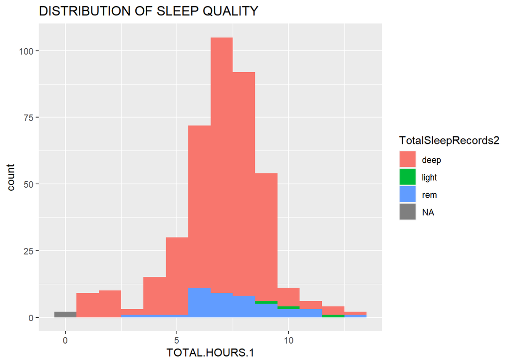

```r
sleep %>%
  ggplot(aes(TOTAL.HOURS.1,fill = TotalSleepRecords2))+
  geom_histogram(binwidth = 1)+
  labs(title = "DISTRIBUTION OF SLEEP QUALITY")
```

```r
library(lubridate)
```

First we have to change the format of the date in the sleep dataset from character to date using the code below.

```r
class(sleep$SleepDay)
```

```
## [1] "character"
```

```r
sleep$DAT <- parse_date_time(sleep$SleepDay, "%a %B %d,%Y")
```

```r
class(sleep$DAT)
```

```
## [1] "POSIXct" "POSIXt"
```

```r
head(sleep$DAT)
```

```
## [1] "2016-04-12 UTC" "2016-04-13 UTC" "2016-04-14 UTC" "2016-04-15 UTC"
## [5] "2016-04-16 UTC" "2016-04-17 UTC"
```

Now that a new date colum has been created from sleepdate column, day of the week will be extracted to form another column

```r
sleep$wday <- wday(sleep$DAT, label = TRUE)
```

```r
head(sleep$wday)
```

```
## [1] Tue Wed Thu Fri Sat Sun
## Levels: Sun < Mon < Tue < Wed < Thu < Fri < Sat
```

```r
summary(sleep$TOTAL.HOURS)
```

```
##    Min. 1st Qu.  Median    Mean 3rd Qu.    Max.    NA's
##   0.000   6.020   7.200   6.958   8.170  13.270      19
```

A plot of sleep time on different days of the week is below

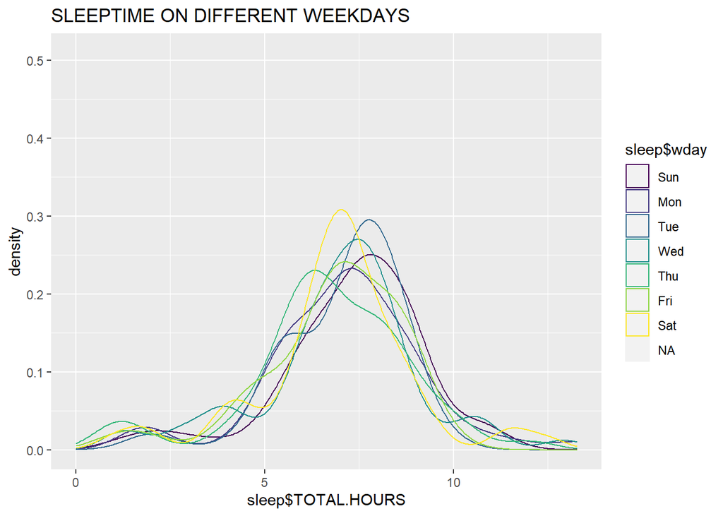

```r
sleep %>%
  ggplot(aes(sleep$TOTAL.HOURS, color = sleep$wday))+
  geom_density()+
  labs(title = "SLEEPTIME ON DIFFERENT WEEKDAYS")
```

### DAILY ACTIVITIES AND CALORIES BURNT

- Physical activies, number of steps, time spent in different activies and calories burnt were tracked differently per minute but their results were later merged in a single dataset making analysis easier. Dataset saved as daily below.`

```r
daily <- read.csv("C://Users//ACER//Downloads//dailyActivity_merged (1).csv")
```

```r
summary(daily)
```

```
##        Id            ActivityDate         TotalSteps    TotalDistance
##  Min.   :1.504e+09   Length:940         Min.   :    0   Min.   : 0.000
##  1st Qu.:2.320e+09   Class :character   1st Qu.: 3790   1st Qu.: 2.620
##  Median :4.445e+09   Mode  :character   Median : 7406   Median : 5.245
##  Mean   :4.855e+09                      Mean   : 7638   Mean   : 5.490
##  3rd Qu.:6.962e+09                      3rd Qu.:10727   3rd Qu.: 7.713
##  Max.   :8.878e+09                      Max.   :36019   Max.   :28.030
##  TrackerDistance  LoggedActivitiesDistance VeryActiveDistance
##  Min.   : 0.000   Min.   :0.0000           Min.   : 0.000
##  1st Qu.: 2.620   1st Qu.:0.0000           1st Qu.: 0.000
##  Median : 5.245   Median :0.0000           Median : 0.210
##  Mean   : 5.475   Mean   :0.1082           Mean   : 1.503
##  3rd Qu.: 7.710   3rd Qu.:0.0000           3rd Qu.: 2.053
##  Max.   :28.030   Max.   :4.9421           Max.   :21.920
##  ModeratelyActiveDistance LightActiveDistance SedentaryActiveDistance
##  Min.   :0.0000           Min.   : 0.000      Min.   :0.000000
##  1st Qu.:0.0000           1st Qu.: 1.945      1st Qu.:0.000000
##  Median :0.2400           Median : 3.365      Median :0.000000
##  Mean   :0.5675           Mean   : 3.341      Mean   :0.001606
##  3rd Qu.:0.8000           3rd Qu.: 4.782      3rd Qu.:0.000000
##  Max.   :6.4800           Max.   :10.710      Max.   :0.110000
##  VeryActiveMinutes FairlyActiveMinutes LightlyActiveMinutes SedentaryMinutes
##  Min.   :  0.00    Min.   :  0.00      Min.   :  0.0        Min.   :   0.0
##  1st Qu.:  0.00    1st Qu.:  0.00      1st Qu.:127.0        1st Qu.: 729.8
##  Median :  4.00    Median :  6.00      Median :199.0        Median :1057.5
##  Mean   : 21.16    Mean   : 13.56      Mean   :192.8        Mean   : 991.2
##  3rd Qu.: 32.00    3rd Qu.: 19.00      3rd Qu.:264.0        3rd Qu.:1229.5
##  Max.   :210.00    Max.   :143.00      Max.   :518.0        Max.   :1440.0
##     Calories
##  Min.   :   0
##  1st Qu.:1828
##  Median :2134
##  Mean   :2304
##  3rd Qu.:2793
##  Max.   :4900
```

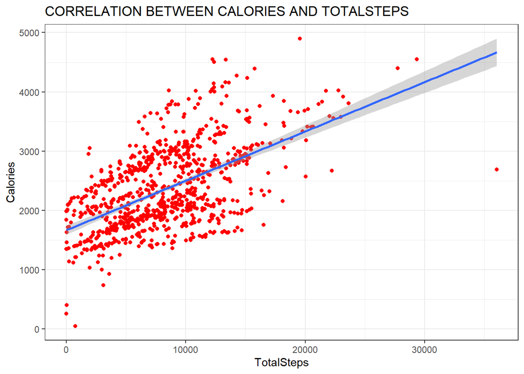

```r
daily %>%
  select(TotalSteps,VeryActiveDistance,SedentaryMinutes,Calories) %>%
  filter(TotalSteps > 0) %>%
  ggplot(aes(x =TotalSteps, y = Calories))+
  geom_point(size = 1.5,alpha = 1, color = "red")+
  geom_smooth(method = "lm")+
  theme_bw()+
  labs(title = "CORRELATION BETWEEN CALORIES AND TOTALSTEPS")
```

* comparing rate of activities per day, respondents are generally non active. They live more of a sedentary lifestyle.

```r
time <- c(1440, 900, 192, 13.6, 21.6)
```

```r
active <- c("totalday", "sedentary", "light", "moderate", "veryactive")
```

```r
activetime <- data.frame(time, active)
```

```r
bp<- ggplot(activetime, aes(x="", y= time, fill = active))+
  geom_bar(width = 1, stat = "identity")
```

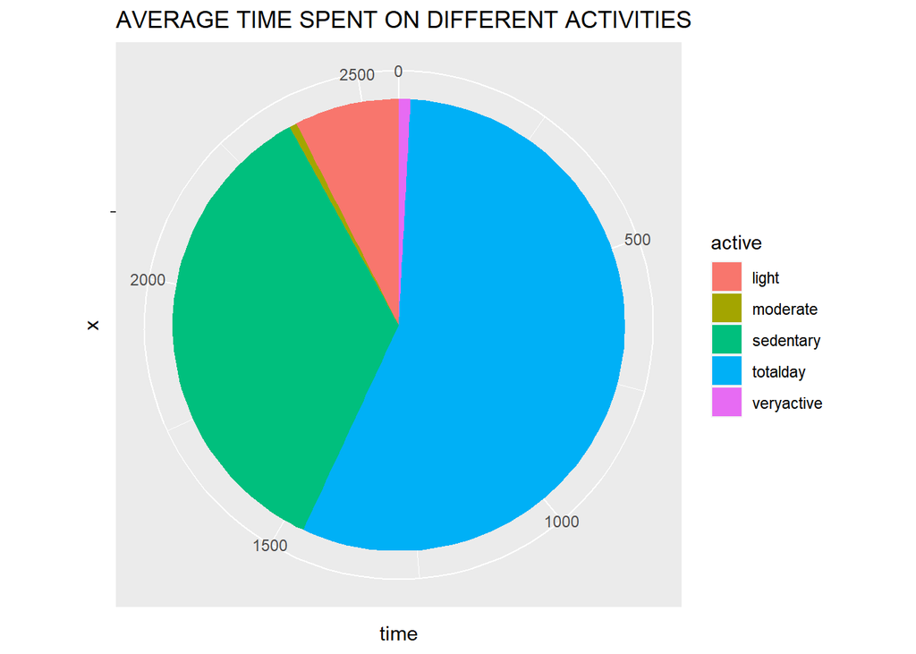

```r
pie <- bp + coord_polar("y", start=0)+
  labs(title = "AVERAGE TIME SPENT ON DIFFERENT ACTIVITIES")
pie
```

- Carrying out a correlation between the different variables of daily activities versus calories. I first removed non numeric and irrelevant variables with the code beneath

```r
dailycor <- subset(daily, select = -c(Id,ActivityDate,LoggedActivitiesDistance,SedentaryActiveDistance,TotalDistance ))
```

```r
names(dailycor)
```

```
##  [1] "TotalSteps"               "TrackerDistance"
##  [3] "VeryActiveDistance"       "ModeratelyActiveDistance"
##  [5] "LightActiveDistance"      "VeryActiveMinutes"
##  [7] "FairlyActiveMinutes"      "LightlyActiveMinutes"
##  [9] "SedentaryMinutes"         "Calories"
```

- secondally i installed the GGally package and made the plots as shown below l

```r
library(GGally)
```

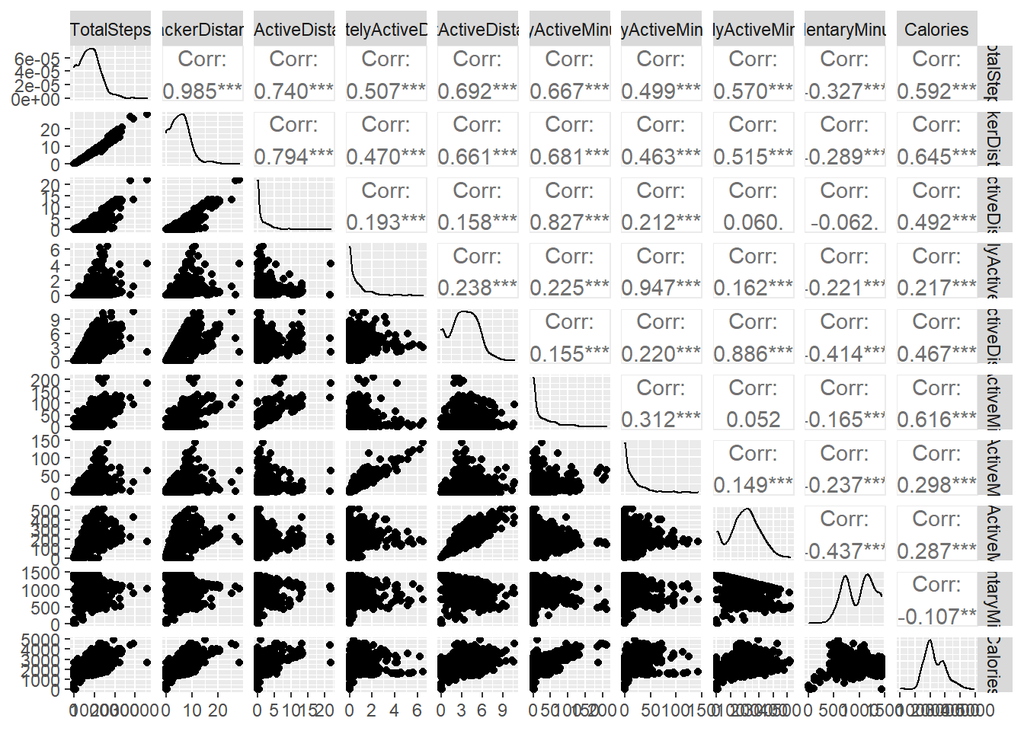

```r
ggpairs(dailycor)
```